```python
import pandas as pd
import logging
import numpy as np
import sys
import matplotlib.pyplot as plt
import time
from sklearn.cross_validation import train_test_split
%pylab inline
```

```python
def init():
    #Loading the dataset
    print('loading the dataset')

    df = pd.read_csv('hw1-data.csv', delimiter=',')
    X = df.values[:,:-1]
    y = df.values[:,-1]

    print('Split into Train and Test')
    X_train, X_test, y_train, y_test = train_test_split(X, y, test_size =100, random_state=10)
    return X_train, X_test, y_train, y_test
#!---init---!
X_train, X_test, y_train, y_test = init()
```

```
loading the dataset
Split into Train and Test
```

# 2. Linear Regression

## 2.1 Feature Normalization

Modify function `feature_normalization` to normalize all the features to [0,1].

> **Answer:**

> Min-Max Scaling is used to normalize all the features.

> $X_{norm} = \frac{X-X_{min}}{X_{max}-X_{min}}$

> When subtracting vector $X_{min}$ from matrix $X$, and dividing $X_{max}-X_{min}$, Numpy's "broadcasting" is used.

```python
#######################################
####Q2.1: Normalization
def feature_normalization(train, test):
    """Rescale the data so that each feature in the training set is in
    the interval [0,1], and apply the same transformations to the test
    set, using the statistics computed on the training set.

    Args:
        train - training set, a 2D numpy array of size (num_instances, num_features)
        test  - test set, a 2D numpy array of size (num_instances, num_features)
    Returns:
        train_normalized - training set after normalization
        test_normalized  - test set after normalization

    """
    # Min-Max Scaling
    train_min = np.min(train,axis=0)
    train_max = np.max(train,axis=0)
    return (train-train_min)/(train_max - train_min+0.0), (test-train_min)/(train_max - train_min+0.0)

#!---Scale---!

print("Scaling all to [0, 1]")
X_train, X_test = feature_normalization(X_train, X_test)
X_train = np.hstack((X_train, np.ones((X_train.shape[0], 1))))  # Add bias term
X_test = np.hstack((X_test, np.ones((X_test.shape[0], 1)))) # Add bias term
```

```
Scaling all to [0, 1]
```

## 2.2 Gradient Descent Setup

1.Write the objective function $J(\theta)$ as a matrix/vector expression, without using an explicit summation sign.

> **ANSWER:**

2.Write down an expression for the gradient of J.

> **ANSWER**:

> $\nabla_{\theta}J(\theta)$

> $= \frac{\partial(\frac{1}{2m}(X\theta-y)^T(X\theta-y))}{\partial(X\theta-y)} \frac{\partial(X\theta-y)}{\partial\theta}$

> $=\frac{1}{m}(X\theta-y)^T X$

3.Use the gradient to write down an approximate expression for $J(\theta+\eta\Delta)-J(\theta)$

> **ANSWER**:

> The gradient at point $\theta$ is the best linear approximation of $J$ at that point.

> $J(\theta+\eta\Delta)-J(\theta) \approx \nabla J(\theta)\Delta\eta$

4.Write down the expression for updating $\theta$ in the gradient descent algorithm. Let $\eta$ be the step size.

> **ANSWER:**

> $\theta_{i+1} = \theta_i-\eta\nabla_{\theta}J$

5.Modify the function `compute_square_loss`, to compute $J(\theta)$ for a given $\theta$.

```python
########################################
####Q2.2a: The square loss function

def compute_square_loss(X, y, theta):
    """
    Given a set of X, y, theta, compute the square loss for predicting y with X*theta

    Args:
        X - the feature vector, 2D numpy array of size (num_instances, num_features)
        y - the label vector, 1D numpy array of size (num_instances)
        theta - the parameter vector, 1D array of size (num_features)

    Returns:
        loss - the square loss, scalar
    """
    loss = np.dot(X, theta) - y
    return 0.5 * np.sum(loss ** 2) / X.shape[0]
```

6.Create a small dataset for which you can compute $J(\theta)$ by hand, and verify that your `compute_square_loss` function returns the correct value.

```python
theta = np.random.rand(X_train.shape[1])
print compute_square_loss(X_train, y_train, theta)
```

```
115.663742555
```

7.Modify the function `compute_square_loss_gradient`, to compute $\nabla_{\theta}J(\theta)$.

```python
###Q2.2b: compute the gradient of square loss function
def compute_square_loss_gradient(X, y, theta):
    """
    Compute gradient of the square loss (as defined in compute_square_loss), at the point theta.

    Args:
        X - the feature vector, 2D numpy array of size (num_instances, num_features)
        y - the label vector, 1D numpy array of size (num_instances)
        theta - the parameter vector, 1D numpy array of size (num_features)

    Returns:
        grad - gradient vector, 1D numpy array of size (num_features)
    """
    m = X.shape[0]
    loss = np.dot(X, theta)-y
    return 1/(m+0.0)*np.dot(X.T, loss)
```

8.Create a small dataset, verify that your `compute_square_loss_gradient` function returns the correct value.

```python
theta = np.random.rand(X_train.shape[1],1)
#print compute_square_loss_gradient(X_train, y_train, theta)
```

```python
X_new = np.random.rand(3,3)
y_new = np.random.rand(3,1)
theta_new = np.random.rand(3,1)
print compute_square_loss_gradient(X_new, y_new, theta_new)
```

```
[[ 0.11544333]
 [ 0.10037056]
 [-0.02513624]]
```

## 2.3 Gradient Checker

```python
###Q2.3a: Gradient Checker
#Getting the gradient calculation correct is often the trickiest part
#of any gradient-based optimization algorithm.  Fortunately, it's very
#easy to check that the gradient calculation is correct using the
#definition of gradient.
#See http://ufldl.stanford.edu/wiki/index.php/Gradient_checking_and_advanced_optimization
def grad_checker(X, y, theta, epsilon=0.01, tolerance=1e-4):
    """Implement Gradient Checker
    Check that the function compute_square_loss_gradient returns the
    correct gradient for the given X, y, and theta.

    Let d be the number of features. Here we numerically estimate the
    gradient by approximating the directional derivative in each of
    the d coordinate directions:
    (e_1 = (1,0,0,...,0), e_2 = (0,1,0,...,0), ..., e_d = (0,...,0,1)

    The approximation for the directional derivative of J at the point
    theta in the direction e_i is given by:
    ( J(theta + epsilon * e_i) - J(theta - epsilon * e_i) ) / (2*epsilon).

    We then look at the Euclidean distance between the gradient
    computed using this approximation and the gradient computed by
    compute_square_loss_gradient(X, y, theta).  If the Euclidean
    distance exceeds tolerance, we say the gradient is incorrect.

    Args:
        X - the feature vector, 2D numpy array of size (num_instances, num_features)
        y - the label vector, 1D numpy array of size (num_instances)
        theta - the parameter vector, 1D numpy array of size (num_features)
        epsilon - the epsilon used in approximation
        tolerance - the tolerance error

    Return:
        A boolean value indicate whether the gradient is correct or not

    """
    true_gradient = compute_square_loss_gradient(X, y, theta) #the true gradient
    num_features = theta.shape[0]
    approx_grad = np.zeros(num_features) #Initialize the gradient we approximate

    for i in range(num_features):
        e_i = np.zeros(num_features)
        e_i[i] = 1
        approx_grad[i] = (compute_square_loss(X, y, theta + epsilon *e_i) -
                          compute_square_loss(X, y, theta + epsilon *e_i))/(2*tolerance+0.0)
    dist = np.sqrt(np.sum((approx_grad-true_gradient))**2)
    correct_grad = dist<tolerance
    assert correct_grad, "Gradient bad: dist %s is greater than tolerance %s" % (dist,tolerance)
    return correct_grad
```

2.Write a generic version of `grad_checker` that will work for any objective function. It should take as parameters a function that computes the gradient of the pbjective function.

```python
#################################################
###Q2.3b: Generic Gradient Checker
def generic_gradient_checker(X, y, theta, objective_func, gradient_func, epsilon=0.01, tolerance=1e-4):
    """
    The functions takes objective_func and gradient_func as parameters. And check whether gradient_func(X, y, theta) returned
    the true gradient for objective_func(X, y, theta).
    Eg: In LSR, the objective_func = compute_square_loss, and gradient_func = compute_square_loss_gradient
    """
    true_gradient = gradient_func(X, y, theta) #the true gradient
    num_features = theta.shape[0]
    approx_grad = np.zeros(num_features) #Initialize the gradient we approximate

    for i in range(num_features):
        e_i = np.zeros(num_features)
        e_i[i] = 1
        approx_grad[i] = (objective_func(X, y, theta + epsilon *e_i) -
                          objective_func(X, y, theta + epsilon *e_i))/(2*tolerance+0.0)
    dist = np.sqrt(np.sum((approx_grad-true_gradient))**2)
    correct_grad = dist<tolerance
    assert correct_grad, "Gradient bad: dist %s is greater than tolerance %s" % (dist,tolerance)
    return correct_grad
```

## 2.4 Batch Gradient Descent

1.Complete `batch_gradient_descent`

```python
####################################
####Q2.4a: Batch Gradient Descent
def batch_grad_descent(X, y, alpha=0.01, num_iter=1000, check_gradient=False):
    """
    In this question you will implement batch gradient descent to
    minimize the square loss objective

    Args:
        X - the feature vector, 2D numpy array of size (num_instances, num_features)
        y - the label vector, 1D numpy array of size (num_instances)
        alpha - step size in gradient descent
        num_iter - number of iterations to run
        check_gradient - a boolean value indicating whether checking the gradient when updating

    Returns:
        theta_hist - store the the history of parameter vector in iteration, 2D numpy array of size (num_iter+1, num_features)
                    for instance, theta in iteration 0 should be theta_hist[0], theta in ieration (num_iter) is theta_hist[-1]
        loss_hist - the history of objective function vector, 1D numpy array of size (num_iter+1)
    """
    num_instances, num_features = X.shape[0], X.shape[1]
    theta = np.ones(num_features) #initialize theta
    theta_hist = theta #Initialize theta_hist
    loss_hist = compute_square_loss(X, y, theta.T) #initialize loss_hist
    for i in range(num_iter):
        if check_gradient:
            grad = grad_checker(X, y, theta)
            print('Grade check:{0}'.format(grad))
        grad = compute_square_loss_gradient(X,y,theta.T)
        theta = theta - alpha*grad.T
        theta_hist = np.vstack((theta_hist, theta))
        loss = compute_square_loss(X, y, theta.T)
        loss_hist = np.vstack((loss_hist, loss))

    return loss_hist,theta_hist
```

```python
X = X_train
y = y_train
loss_return, theta_return = batch_grad_descent(X, y)
loss_return
```

```
array([[ 441.43426102],
       [ 285.54947422],
       [ 185.24897342],
       ...,
       [   1.86585135],
       [   1.86503146],
       [   1.86421264]])
```

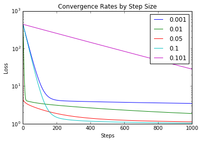

```python
num_iter = 1000
def converge_test(X, y):
    step_sizes = np.array([0.001, 0.01, 0.05, 0.1, 0.101])
    for step_size in step_sizes:
        loss_hist,_ = batch_grad_descent(X,y,alpha=step_size, num_iter=num_iter)
        plt.plot(loss_hist, label=step_size)

    plt.xlabel('Steps')
    plt.ylabel('Loss')
    plt.yscale('log')
    plt.title('Convergence Rates by Step Size')
    plt.legend()
    plt.show()

converge_test(X_train,y_train)
```

3.(Option)backtracking line search

```python
####################################
###Q2.4b: Implement backtracking line search in batch_gradient_descent
###Check http://en.wikipedia.org/wiki/Backtracking_line_search for details
#TODO
```

## 2.5 Ridge Regression

1.Compute the gradient of $J(\theta)$ and write down the expression for updating $\theta$ in the gradient descent algprithm

> **ANSWER**:

> $\nabla_{\theta}J(\theta)=\frac{1}{m}(X\theta-y)^T X +2\lambda\theta$

2.Implement `compute_regularized_square_loss_gradient`

```python
def compute_regularized_square_loss_gradient(X, y, theta, lambda_reg=1):
    """
    Compute gradient of the square loss (as defined in compute_square_loss), at the point theta.

    Args:
        X - the feature vector, 2D numpy array of size (num_instances, num_features)
        y - the label vector, 1D numpy array of size (num_instances)
        theta - the parameter vector, 1D numpy array of size (num_features)

    Returns:
        grad - gradient vector, 1D numpy array of size (num_features)
    """
    regularization_term = 2.0 * lambda_reg * theta

    grad = compute_square_loss_gradient(X, y, theta) + regularization_term
    return grad
```

3.Implement `regularized_grad_descent`

```python
###################################################
###Q2.5b: Batch Gradient Descent with regularization term
def regularized_grad_descent(X, y, alpha=0.1, lambda_reg=1, num_iter=1000):
    """
    Args:
        X - the feature vector, 2D numpy array of size (num_instances, num_features)
        y - the label vector, 1D numpy array of size (num_instances)
        alpha - step size in gradient descent
        lambda_reg - the regularization coefficient
        numIter - number of iterations to run

    Returns:
        theta_hist - the history of parameter vector, 2D numpy array of size (num_iter+1, num_features)
        loss_hist - the history of regularized loss value, 1D numpy array
    """
    (num_instances, num_features) = X.shape
    theta = np.ones(num_features)  # Initialize theta
    theta_hist = np.zeros((num_iter + 1, num_features))  # Initialize theta_hist
    loss_hist = np.zeros(num_iter + 1)  # Initialize loss_hist

    for i in range(num_iter + 1):
        loss_hist[i] = compute_square_loss(X, y, theta) + lambda_reg * np.sum(theta ** 2)
        theta_hist[i] = theta

        grad = compute_regularized_square_loss_gradient(X, y, theta, lambda_reg)
        #theta = theta - alpha * grad/np.linalg.norm(grad)
        theta = theta - alpha * grad

    return loss_hist,theta_hist
```

```python
loss, theta = regularized_grad_descent(X_train, y_train, 0.01, 1)
loss
```

```
array([ 490.43426102,  303.0924192 ,  188.40878738, ...,    3.82298295,
          3.82298295,    3.82298295])
```

4.Explain why making B large decreases the effective regulatization on the bias term, and how we can make that regularization as weak as we like(though not zero)

> **ANSWER:**

> The gradient descent algorithm seeks to minimize the loss function by driving the coeffecient of the linear function, i.e. $B\rightarrow\infty, \theta_{bias}\rightarrow0$. So using a large B will decrease the impact of regulation $\lambda$ on the coeffecient of the bias term.

5.Choose a reasonable step size. Plot the training loss and the validation loss(without the regulation) as a function of $\lambda$.

```python
#############################################
##Q2.5c: Visualization of Regularized Batch Gradient Descent
##X-axis: log(lambda_reg)
##Y-axis: square_loss
def vis_regularized_batch_gradient_descent(X_train, X_test, y_train, y_test, lambdas):
    stepSize = 0.00001
    train_error = np.zeros(lambdas.shape[0])
    validation_error = np.zeros(lambdas.shape[0])
    for i, lamb in enumerate(lambdas):
        losses, thetas = regularized_grad_descent(X_train, y_train, stepSize, lambda_reg=lamb, num_iter=10000)
        train_error[i] = compute_square_loss(X_train, y_train, thetas[-1,:])
        validation_error[i] = compute_square_loss(X_test, y_test, thetas[-1,:])

    print "Min lambda: " + str(lambdas[np.argmin(validation_error)])
    print "Min training error: " + str(train_error.min())
    print "Min validation error: " + str(validation_error.min())
    plt.plot(np.log(lambdas), train_error,label="Training error", c='b')
    plt.plot(np.log(lambdas), validation_error,label="Validation Error" ,c='r')
    plt.legend()
    plt.xlabel("Lambda (log)")
    plt.ylabel("Error")
    plt.show()
```

```
Min lambda: 7.75
Min training error: 4.09907511755
Min validation error: 2.35093006421
```

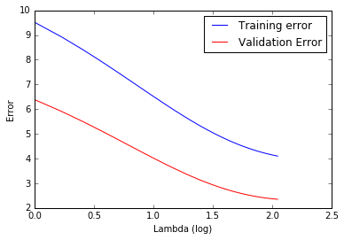

```python
#lambdas = np.array([1e-7, 1e-5, 1e-3, 1e-1, 1, 10, 100,1000])
lambdas = np.arange(1, 8 , 0.25)
vis_regularized_batch_gradient_descent(X_train, X_test, y_train, y_test, lambdas)
```

## 2.6 Stochastic Gradient Descent

1.Write down the update rule for $\theta $ in SGD.

> **ANSWER**:

> $\theta_{t+1}=\theta_t - \eta\nabla_{\theta}\frac{1}{2}(h_{\theta}(x_i)-y_i)$

> where $(x_i,y_i)$ is randomly chosen porint.

2.Implement `stochastic_grad_descent`.

```python
#############################################
# ##Q2.6a: Stochastic Gradient Descent
def stochastic_grad_descent(X, y, alpha=0.001, lambda_reg=1, num_iter=1000):
    """
    In this question you will implement stochastic gradient descent with a regularization term

    Args:
        X - the feature vector, 2D numpy array of size (num_instances, num_features)
        y - the label vector, 1D numpy array of size (num_instances)
        alpha - string or float. step size in gradient descent
                NOTE: In SGD, it's not always a good idea to use a fixed step size. Usually it's set to 1/sqrt(t) or 1/t
                if alpha is a float, then the step size in every iteration is alpha.
                if alpha == "1/sqrt(t)", alpha = 1/sqrt(t)
                if alpha == "1/t", alpha = 1/t
        lambda_reg - the regularization coefficient
        num_iter - number of epochs (i.e number of times) to go through the whole training set

    Returns:
        theta_hist - the history of parameter vector, 3D numpy array of size (num_iter, num_instances, num_features)
        loss hist - the history of regularized loss function vector, 2D numpy array of size(num_iter, num_instances)
    """
    num_instances, num_features = X.shape[0], X.shape[1]
    theta = np.ones(num_features)  # Initialize theta


    theta_hist = np.zeros((num_iter, num_instances, num_features))  # Initialize theta_hist
    loss_hist = np.zeros((num_iter, num_instances))  # Initialize loss_hist
    # TODO
    if isinstance(alpha, str):
        if alpha == '1/t':
            f = lambda x: 1.0 / x
        elif alpha == '1/sqrt(t)':
            f = lambda x: 1.0 / np.sqrt(x)
        alpha = 0.01
    elif isinstance(alpha, float):
        f = lambda x: 1
    else:
        return

    t0 = time.time()

    for t in range(num_iter):


        for i in range(num_instances):
            gamma_t = alpha * f((i+1)*(t+1))

            theta_hist[t , i] = theta
            # compute loss for current theta
            loss = np.dot(X[i], theta) - y[i]
            # reg. term
            regulariztion_loss = lambda_reg * np.dot(theta.T,theta)
            # squared loss
            loss_hist[t, i] = (0.5) * (loss) ** 2 + regulariztion_loss

            regularization_penalty = 2.0 * lambda_reg * theta
            grad = X[i] * (loss) + regularization_penalty
            theta = theta - gamma_t * grad

    t1 = time.time()
    print "Average time per epoch:: " + str((t1 - t0) / num_iter)
    return theta_hist, loss_hist
```

```python
def convergence_tests_batch_vs_stochastic(X,y):
    alphas = ['1/t','1/sqrt(t)',0.0005,0.001]
    fig = plt.figure(figsize=(20,8))
    plt.subplot(121)

    for alpha in alphas:
        [thetas,losses] = stochastic_grad_descent(X, y, alpha, 5.67, 5)
        plt.plot(np.log(losses.ravel()),label='Alpha:'+str(alpha))

    plt.legend()
```

```
Average time per epoch:: 0.000810813903809
Average time per epoch:: 0.000934219360352
Average time per epoch:: 0.00155262947083
Average time per epoch:: 0.00154900550842
```

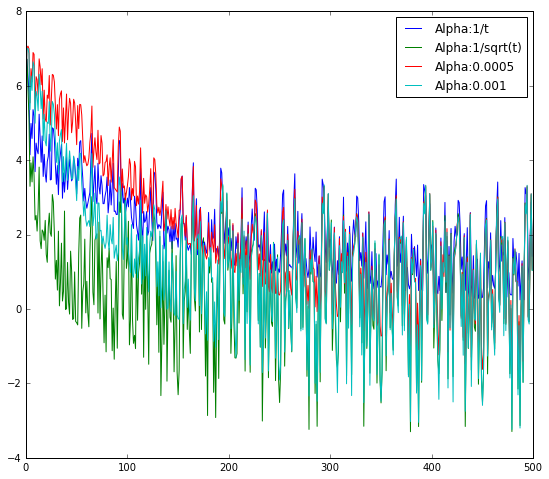

```python
convergence_tests_batch_vs_stochastic(X_train,y_train)
```

```python
################################################
###Q2.6b Visualization that compares the convergence speed of batch
###and stochastic gradient descent for various approaches to step_size
##X-axis: Step number (for gradient descent) or Epoch (for SGD)
##Y-axis: log(objective_function_value)
```

## 3.Risk Minimization

1.Show that for the square loss $\ell(\hat y-y)=\frac{1}{2}(y-\hat y)^2$, the Bayes decision function is a $f^*(x)=\mathbb{E}[Y |X=x]$

$R(f)$

$=\frac{1}{2}\mathbb{E}[(f(x)-y)^2]$

$=\frac{1}{2}\mathbb{E}[(y-\hat y)^2|x]$

$=\frac{1}{2}\mathbb{E}[(y^2-2y\hat y+\hat y^2)|x]$

$=\frac{1}{2}(\mathbb{E}[y^2|x]-2\mathbb{E}[y|x]+\hat y^2)$

Hence,

$\frac{\partial R(f)}{\partial \hat y}=2\hat y - 2\mathbb{E}[y|x]$

$\hat y = \mathbb{E}[y|x]$

2.Show that for the absolute loss $\ell(\hat y,y)=|y-\hat y|$, the Bayes function is a $f^*(x)=median[Y|X=x].$

$R(f)$

$=\mathbb{E}[|y-\hat y||x]$

$=\int |y-\hat y|\pi(y|x)dy$

$=\int_{y\leq\hat y}(\hat y-y)\pi(y|x)dy+\int_{y\geq\hat y}(y-\hat y)\pi(y|x)dy$

$\frac{\partial R(f)}{\partial \hat y}$

$= -\int_{y \geq \hat{y}}\pi(y|x)dy + (\hat{y}-\hat{y})(1)-(\hat{y}-y^+)(0) +\int_{y\leq \hat{y}}\pi(y|x)dy + (y^- - \hat{y})(0)- (\hat{y}-\hat{y})(1)$

$=-\int_{y \geq \hat{y}}\pi(y|x)dy +\int_{y\leq \hat{y}}\pi(y|x)dy =0$

Hence,

$P(y\geq\hat{y}) = P(y\leq \hat{y})$